# Regression Model

kuriboh

9/27/2020

## This chunk loads the libraries used in this report

```r
library(ggplot2)
library(datasets)
```

## Executive summary

This report analyzes the mtcars database. The main purpose is to see if there is any direct relationship between mpg and transmission.

## First analysis

- Skewing checking  
  Exploring the dataset, I want to check if the data is skewed on the am variable. If these is any on the either class, the result might be not correct.

```r
data(mtcars)
table(mtcars$am)
```

```
##
##  0  1
## 19 13
```

- Exploring correlations  
  As the following step, I checked the correlation between mpg and the other variables.

```r
cor(mtcars$mpg, mtcars)
```

```
##      mpg       cyl       disp         hp      drat         wt     qsec
## [1,]   1 -0.852162 -0.8475514 -0.7761684 0.6811719 -0.8676594 0.418684
##             vs        am      gear       carb
## [1,] 0.6640389 0.5998324 0.4802848 -0.5509251
```

We all know that the heavier cars consume more fuel than the light ones. And according to the above result, the wt (weight) has the “nearest” correlation with the mpg, and followed by cyl (cylinders), this really makes sense. For the convenience, I will name this observation (1)

- For better visualization, I will name the tranmission types

```r
mtcars$am <- as.factor(mtcars$am)
levels(mtcars$am) <- c("manual", "auto")
```

## Trying models

At first, I will plot the mpg by the type of transmission.

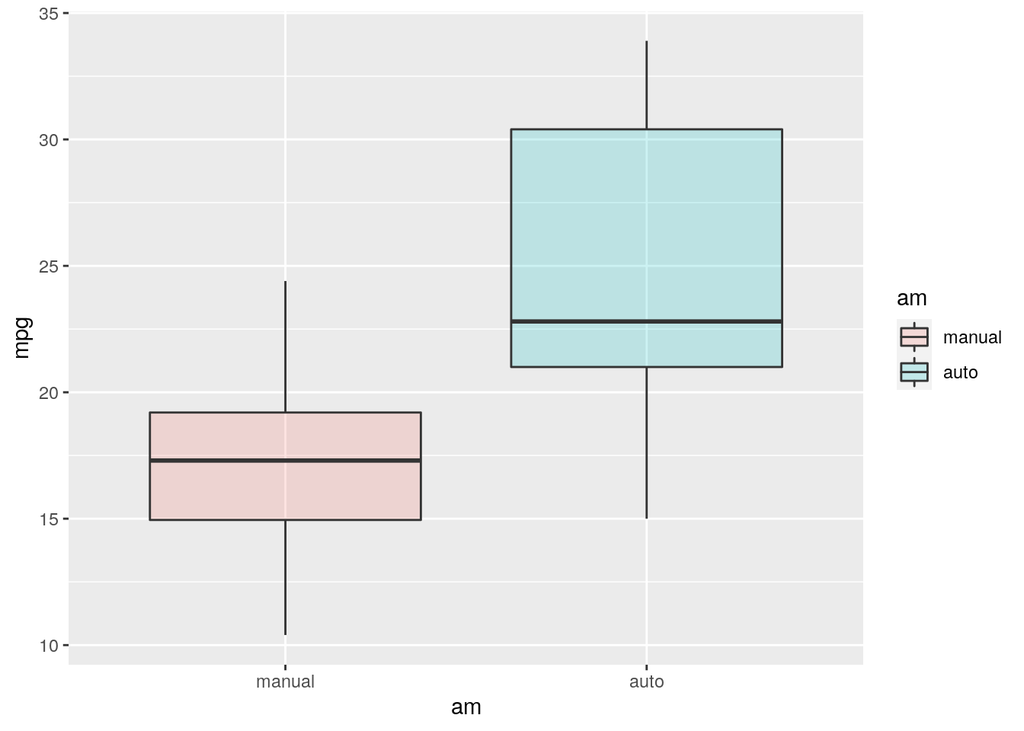

```r
ggplot(mtcars, aes(x=am, y=mpg, fill=am)) + geom_boxplot(alpha=0.2)
```

- First model  
  To verify, I will use a simple linear model.

```r
model_1 <- lm(mtcars$mpg ~ mtcars$am)
summary(model_1)
```

```
##
## Call:
## lm(formula = mtcars$mpg ~ mtcars$am)
##
## Residuals:
##     Min      1Q  Median      3Q     Max
## -9.3923 -3.0923 -0.2974  3.2439  9.5077
##
## Coefficients:
##               Estimate Std. Error t value Pr(>|t|)
## (Intercept)     17.147      1.125  15.247 1.13e-15 ***
## mtcars$amauto    7.245      1.764   4.106 0.000285 ***
## ---
## Signif. codes:  0 '***' 0.001 '**' 0.01 '*' 0.05 '.' 0.1 ' ' 1
##
## Residual standard error: 4.902 on 30 degrees of freedom
## Multiple R-squared:  0.3598, Adjusted R-squared:  0.3385
## F-statistic: 16.86 on 1 and 30 DF,  p-value: 0.000285
```

** Second model  
Looks back at the observation (1), I want to check if the cylinders affect mpg.

```r
model_2 <- lm(mtcars$mpg ~ as.numeric(mtcars$am) + mtcars$wt + mtcars$cyl)
summary(model_2)
```

```
##
## Call:
## lm(formula = mtcars$mpg ~ as.numeric(mtcars$am) + mtcars$wt +
##     mtcars$cyl)
##
## Residuals:
##     Min      1Q  Median      3Q     Max
## -4.1735 -1.5340 -0.5386  1.5864  6.0812
##
## Coefficients:
##                       Estimate Std. Error t value Pr(>|t|)
## (Intercept)            39.2414     3.7219  10.543 2.96e-11 ***
## as.numeric(mtcars$am)   0.1765     1.3045   0.135  0.89334
## mtcars$wt              -3.1251     0.9109  -3.431  0.00189 **
## mtcars$cyl             -1.5102     0.4223  -3.576  0.00129 **
## ---
## Signif. codes:  0 '***' 0.001 '**' 0.01 '*' 0.05 '.' 0.1 ' ' 1
##
## Residual standard error: 2.612 on 28 degrees of freedom
## Multiple R-squared:  0.8303, Adjusted R-squared:  0.8122
## F-statistic: 45.68 on 3 and 28 DF,  p-value: 6.51e-11
```

The weight affects the mpg in 3.12mpg per weight unit, the number of cylinders also has something to say but the transmission has a very low impact.

- Third model  
  Let’s look at observation (1) again, I will check if there is any correlation between weights and transmission types.

```r
cor(as.numeric(mtcars$am), mtcars$wt)
```

```
## [1] -0.6924953
```

Now lets see on a plot.

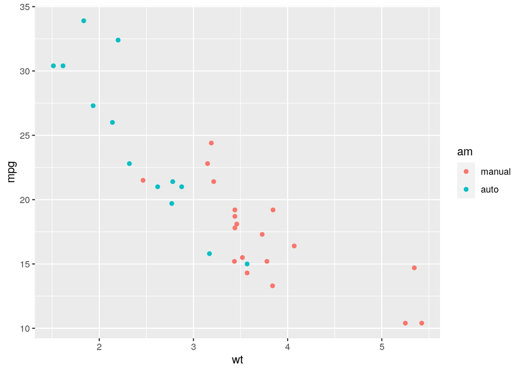

```r
ggplot(mtcars, aes(x=wt, y=mpg, color=am)) + geom_point()
```

From this, I want to try to use another model, similar to the previous ones, but with both weight and transmission types as predictor for mpg.

```r
model_3 <- lm(mtcars$mpg ~ as.numeric(mtcars$am) + mtcars$wt)
summary(model_3)
```

```
##
## Call:
## lm(formula = mtcars$mpg ~ as.numeric(mtcars$am) + mtcars$wt)
##
## Residuals:
##     Min      1Q  Median      3Q     Max
## -4.5295 -2.3619 -0.1317  1.4025  6.8782
##
## Coefficients:
##                       Estimate Std. Error t value Pr(>|t|)
## (Intercept)           37.34517    4.36918   8.547 2.04e-09 ***
## as.numeric(mtcars$am) -0.02362    1.54565  -0.015    0.988
## mtcars$wt             -5.35281    0.78824  -6.791 1.87e-07 ***
## ---
## Signif. codes:  0 '***' 0.001 '**' 0.01 '*' 0.05 '.' 0.1 ' ' 1
##
## Residual standard error: 3.098 on 29 degrees of freedom
## Multiple R-squared:  0.7528, Adjusted R-squared:  0.7358
## F-statistic: 44.17 on 2 and 29 DF,  p-value: 1.579e-09
```

Weight influences -5.35 over mpg but transmission is neutral (0.02).

The last step, comparing the three models:

```r
anova(model_1, model_2, model_3)
```

|  | Res.Df | RSS | Df | Sum of Sq | F | Pr(>F) |
| --- | --- | --- | --- | --- | --- | --- |
| 1 | 30 | 720.8966 | NA | NA | NA | NA |
| 2 | 28 | 191.0471 | 2 | 529.84954 | 38.82757 | 8.428366e-09 |
| 3 | 29 | 278.3197 | -1 | -87.27264 | 12.79074 | 1.291605e-03 |

## Residual diagnosing

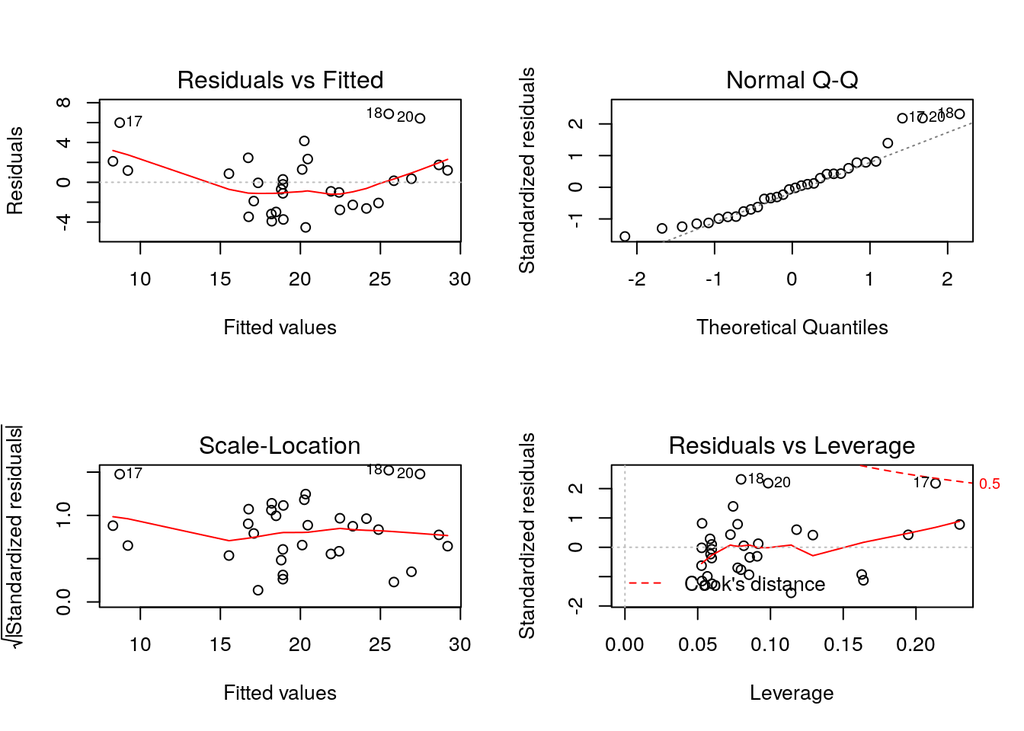

```r
par(mfrow=c(2, 2))
plot(model_3)
```